# Why Computation?

BIOL 5/6800 — Intro to Comp Bio

## Today’s objectives

- Why computational biology?
- Intro to Python & marimo notebooks
- Exercise 4
  - Learning Python and notebooks

# Why computational biology?

## Origins of Comp Bio

- 1952: Fred Sanger sequenced first protein (insulin)
- Margaret Dayhoff & colleagues stored protein sequences in the Protein Information Resource (1960s & 70s)
- 1960s: Dayhoff & others use computers to infer phylogenies

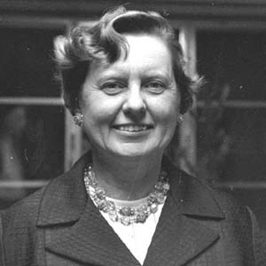

Margaret Dayhoff

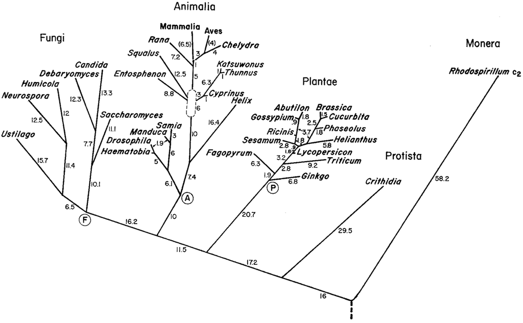

McLaughlin & Dayhoff 1973<sup>1</sup>

[^1]: McLaughlin and Dayhoff (1973)

## Biology became a data science

- One human genome: ~3.1 billion base pairs
- One NovaSeq run: tens of billions of reads
- GenBank, SRA, UniProt, PDB: petabytes, doubling every couple of years
- Sequencing costs have fallen faster than computing has gotten cheaper

The bottleneck in modern biology is rarely *generating* data. It is deciding what to **do** with it.

**Example 1 — Reading a genome you never see**

You sequence a bacterial isolate and get back 4 million short reads, each ~150 bp, in random order, with errors.

**The question:** what is the genome?

**The problem:** this is a jigsaw puzzle with millions of pieces, no picture on the box, some pieces duplicated, and some pieces wrong.

Nobody solves this by hand. An *assembly algorithm* does — by building a graph of overlapping *k*-mers and finding a path through it.

**Example 2 — Pathogen surveillance in real time**

During SARS-CoV-2, sequences were deposited daily and phylogenies were rebuilt continuously to track which lineages were spreading where

That pipeline is a stack of algorithms:

- align millions of genomes to a reference
- infer a tree relating them
- map the tree onto geography and time

If the tree takes six weeks to compute, the answer is useless. **Speed is not a convenience here — it is the whole point.**

## The takeaway

> A biological question becomes a computational question when we have to specify **exactly how** to get from data to answer.

## Comp Bio is also a mindset

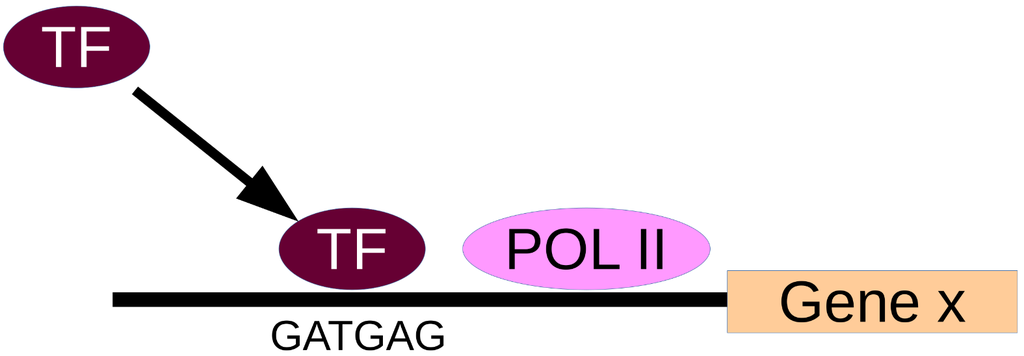

**Biology**: GATGAG sequence is necessary and sufficient to induce expression

**Comp Bio**:

- What is probability of TF binding given GATGAG?
  - $P$(TF binding | GATGAG)
- What is the probability of gene expression?
  - $P$( expression | GATGAG & TF)

Biology isn’t black & white: Think probabilistically using models!

# Intro to Python

## What is Python?

It’s a programming language that is

- Interpreted
- Largely procedural, but flexible
- Terse and clear
- “Pseudocode that works”
- Comes with standard libraries for interacting with the OS
- Diverse, stable libraries for work across many domains
- Industry standard in many fields: Machine learning, data science

## What is a Python notebook?

- An interactive web-based document that allows you to combine runnable Python code, formatted text, and visualizations in one place.
- Composed of modular building blocks called “cells”
  - Instead of running a whole script of Python code, snippets of code in each cell run individually

## Types of cells

**Code (Python) cells**

Snippets of Python code that run individually; output of code appears underneath the cell

**Markdown cells:**

Formatted text and images created using Markdown syntax; used to explain/document the code

## What is marimo?

- One type of Python notebook
- Jupyter is another type that is more popular

So, why marimo?

## Why marimo?

IMHO, marimo solved two big problems with other types of notebooks:

- Results can vary depending on the order cells are run
  - marimo solves this by being “**reactive**”
- The plain text files of other notebooks are illegible (nested in JSON syntax)
  - marimo is pure Python

## What is molab?

- A free, cloud-hosted workspace for running marimo Python notebooks
- The name is a play on Google colab, a popular service for Jypyter notebooks
- It will be our primary means of practicing comp bio

## Ten simple rules

For biologists learning to program<sup>1</sup>

1. Begin with the end in mind
2. Baby steps are steps
3. Immersion is the best learning tool
4. Phone a friend
5. Learn how to ask questions
[^2]: Carey and Papin (2018)

## Ten simple rules

For biologists learning to program<sup>1</sup>

6. Don’t reinvent the wheel
7. Develop good habits early on
8. Practice makes perfect
9. Teach yourself
10. Just do it
[^3]: Carey and Papin (2018)

# Exercise 4

## Intro to Python & marimo

We are transitioning to marimo Python notebooks in molab as our primary environment for learning comp bio

The [class website](https://phyletica.org/intro-to-comp-bio/) ([aub.ie/icb](https://phyletica.org/intro-to-comp-bio/)) has instructions for Python notebook exercises:

1. Go to [molab](https://molab.marimo.io) and make sure you’re logged in
2. Click the notebook link on the class website
3. Click the “Fork” button

# References

Carey, Maureen A., and Jason A. Papin. 2018. “Ten Simple Rules for Biologists Learning to Program.” *PLOS Computational Biology* 14 (1): 1–11. https://doi.org/10.1371/journal.pcbi.1005871.

McLaughlin, P. J., and M. O. Dayhoff. 1973. “Eukaryote Evolution: A View Based on Cytochrome c Sequence Data.” *Journal of Molecular Evolution* 2 (2): 99–116. https://doi.org/10.1007/BF01653990.